# Ejemplo de documento Rmarkdown

Mathieu Kessler

17/02/2015

## Introducción

Este documento sirve para ilustrar el modo Rmardown, que permite crear documentos dinámicos que ejecuten bloques de código R cuando se generen con dos objetivos:

- Conseguir la reproductibilidad del análisis realizado
- Facilitar la generación de informes que se puedan adaptar con facilidad si hay cambios en los datos de entrada.

## Indicadores básicos del conjunto de datos “constitución”

El número de filas que contiene el conjunto de datos considerados es 6, mientras que el número de columnas es 2.

### Media y desviación típica

Podemos calcular indicadores asociados al conjunto de datos que consideramos,

```r
mean(constitución$peso)
```

```
## [1] 70
```

```r
mean(constitución$altura)
```

```
## [1] 170.3
```

### Representación gráfica

Es útil realizar una representación gráfica de peso y altura.

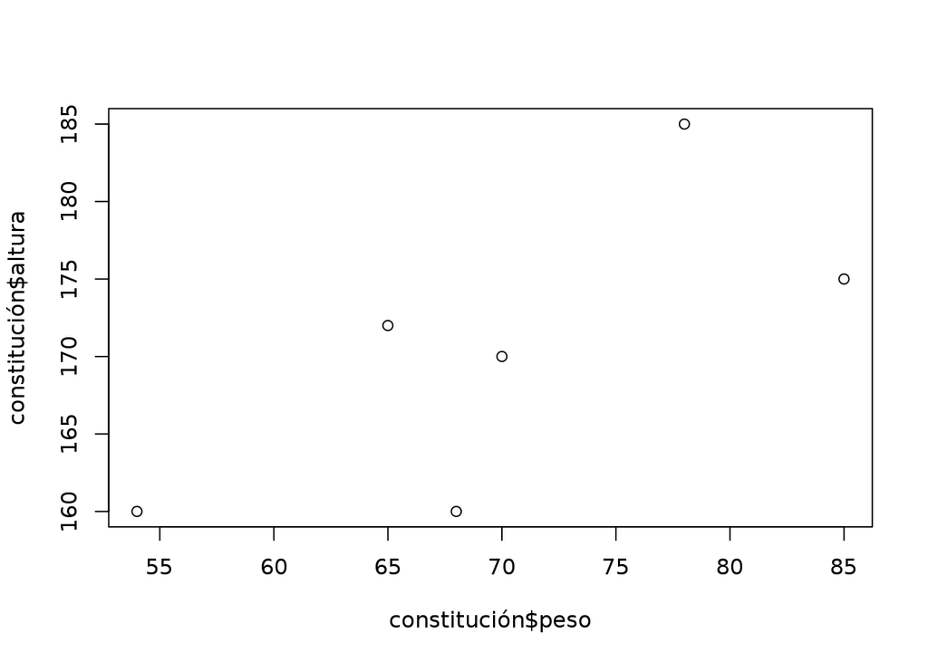

## Calculo del índice de masa corporal.

> El índice de masa corporal (IMC) es una medida de asociación entre la masa y la talla de un individuo ideada por el estadístico belga Adolphe Quetelet, por lo que también se conoce como índice de Quetelet. (Wikipedia)

Se puede encontrar más información en la Wikipedia: [enlace al artículo sobre IMC](http://es.wikipedia.org/wiki/%C3%8Dndice_de_masa_corporal), donde aparece la clasificación de los valores del IMC según la OMC.

Si queremos calcular el IMC, añadimos una columna al conjunto de datos

```r
constitución$IMC = constitución$peso / ((constitución$altura /100)^2)
```

Y podemos ver su resumen en la tabla siguiente

| Número de datos | Media | Desviación típica |
| --- | --- | --- |
| 6 | 24.0657 | 2.635 |

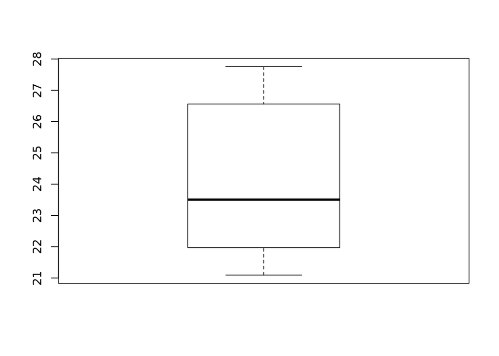